# Data Analysis overview of Telangana Tourism

By Nitin Madas, Kaushal Joshi

# Telangana

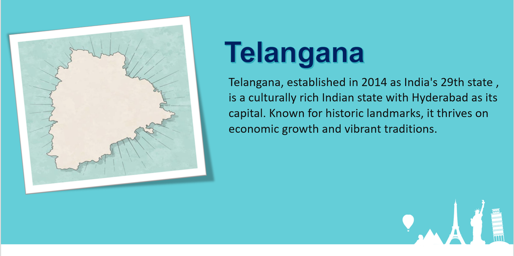

# Data Description

[figure not shown]

```r
# Getting data from different csv files and combining them into one file

input_path = './%s_%s.csv'

domestic_path = 'domestic_visitors/domestic_visitors'
foreign_path = 'foreign_visitors/foreign_visitors'

all_domestic_data <- data.frame()
all_foreign_data <- data.frame()


for( year in years){
  file_path_domestic = sprintf(input_path, domestic_path, year)
  all_domestic_data =  rbind(all_domestic_data, read.csv(file_path_domestic))

  file_path_foreign = sprintf(input_path, foreign_path, year)
  all_foreign_data =  rbind(all_foreign_data, read.csv(file_path_foreign))

}

output_path = './%s.csv'

write.csv(all_domestic_data, sprintf(output_path, domestic_path), row.names=F)
write.csv(all_foreign_data, sprintf(output_path, foreign_path), row.names=F)
```

```r
# Loading data sets
domestic_vis = read.csv('./domestic_visitors/domestic_visitors.csv')
foreign_vis = read.csv('./foreign_visitors/foreign_visitors.csv')

head(domestic_vis)
```

```
##   district       date    month year visitors
## 1 Adilabad 01-01-2016  January 2016   792136
## 2 Adilabad 01-02-2016 February 2016   937820
## 3 Adilabad 01-03-2016    March 2016   582946
## 4 Adilabad 01-04-2016    April 2016   341948
## 5 Adilabad 01-05-2016      May 2016   252887
## 6 Adilabad 01-06-2016     June 2016   368237
```

```r
head(foreign_vis)
```

```
##   district       date    month year visitors
## 1 Adilabad 01-01-2016  January 2016        2
## 2 Adilabad 01-02-2016 February 2016        0
## 3 Adilabad 01-03-2016    March 2016        2
## 4 Adilabad 01-04-2016    April 2016        0
## 5 Adilabad 01-05-2016      May 2016        0
## 6 Adilabad 01-06-2016     June 2016        0
```

# Data Cleaning

#### In Domestic visitors, There are **345** Null Values out of **1512** Values

#### So, there are **22.82%** Null values

#### In Foreign visitors, There are **320** Null Values out of **1512** Values

#### So, there are **21.16%** Null values

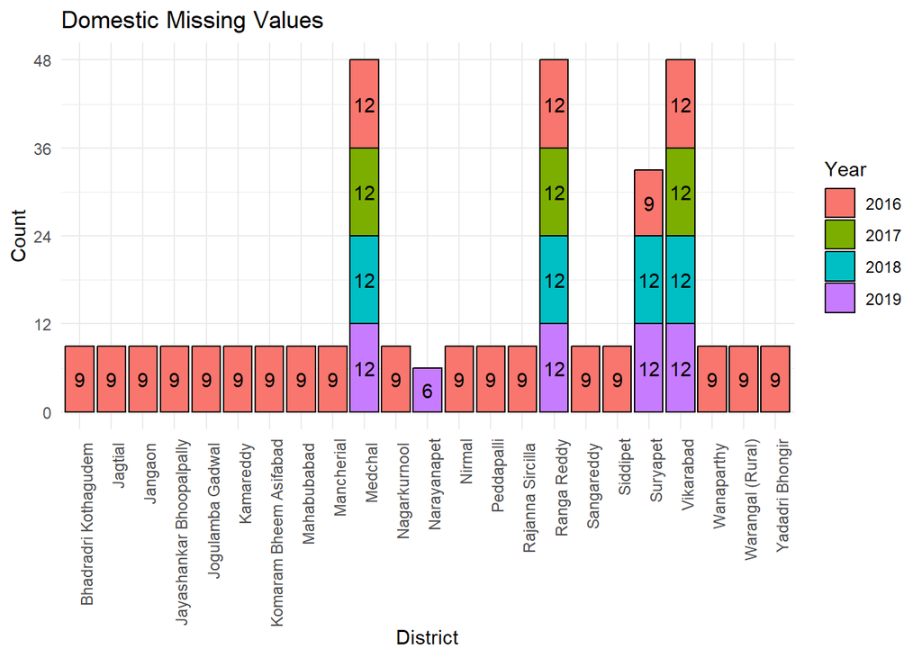

```r
# Lets try to understand where these null values reside in our data
null_vis <- domestic_vis[is.na(domestic_vis$visitors), ]


# Group the data and count occurrences
count_data <- null_vis %>%
  group_by(district, year) %>%
  summarize(count = n())

# count_data %>% as_tibble() %>% print(n=40)


# Create the stacked bar plot
dom_plot = ggplot(count_data, aes(x = district, y = count, fill = as.factor(year)  ) )+
  geom_bar(stat = "identity",color = "black") +
    geom_text(aes(label = count, group = year), position = position_stack(vjust = 0.5)) +
  scale_y_continuous(breaks = seq(0, 50, by = 12)) +

  labs(x = "District", y = "Count", title = "Domestic Missing Values") +
  scale_fill_discrete(name = "Year") +
  theme_minimal() +
  theme(axis.text.x = element_text(angle = 90, hjust = 1))

# Lets try to understand where these null values reside in our data
null_vis_fore <- foreign_vis[is.na(foreign_vis$visitors), ]


# Group the data and count occurrences
count_data_fore <- null_vis_fore %>%
  group_by(district, year) %>%
  summarize(count = n())

fore_plot = ggplot(count_data_fore, aes(x = district, y = count, fill = as.factor(year)  ) )+
  geom_bar(stat = "identity",color = "black") +
    geom_text(aes(label = count, group = year), position = position_stack(vjust = 0.5)) +
  scale_y_continuous(breaks = seq(0, 50, by = 12)) +

  labs(x = "District", y = "Count", title = "Foreign Missing Values") +
  scale_fill_discrete(name = "Year") +
  theme_minimal() +
  theme(axis.text.x = element_text(angle = 90, hjust = 1))

dom_plot
```

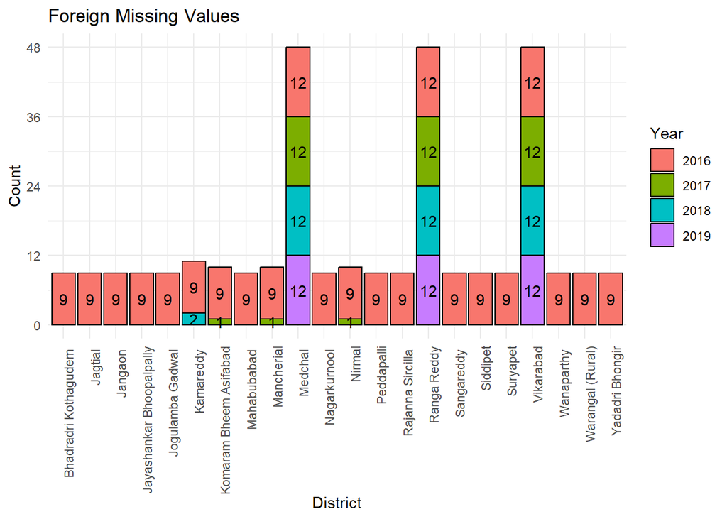

```r
fore_plot
```

#### Cleaning and Imputing the significant values

```r
calculate_missing_percentage <- function(data, group_columns, value_column) {
  # Calculate missing values per specified group columns
  missing_data <- data %>%
    group_by(across(all_of(group_columns))) %>%
    summarize(
      total_rows = n(),
      missing_values = sum(is.na({{ value_column }}))
    )

  # Calculate missing percentage
  missing_data <- missing_data %>%
    mutate(missing_percentage = (missing_values / total_rows) * 100)

  # Filter rows with missing percentage equal to 100%
  missing_all_values <- missing_data %>%
    filter(missing_percentage >25)

  return(missing_all_values)
}
```

```r
result_district <- calculate_missing_percentage(domestic_vis, c("district"), visitors)
result_foreign <- calculate_missing_percentage(foreign_vis, c("district"), visitors)
result_district_year_month <- calculate_missing_percentage(domestic_vis, c("month","year"), visitors)
result_district
```

```
## # A tibble: 5 × 4
##   district      total_rows missing_values missing_percentage
##   <chr>              <int>          <int>              <dbl>
## 1 "Medchal "            48             48              100
## 2 "Narayanapet"         12              6               50
## 3 "Ranga Reddy"         48             48              100
## 4 "Suryapet"            48             33               68.8
## 5 "Vikarabad"           48             48              100
```

```r
result_foreign
```

```
## # A tibble: 3 × 4
##   district      total_rows missing_values missing_percentage
##   <chr>              <int>          <int>              <dbl>
## 1 "Medchal "            48             48                100
## 2 "Ranga Reddy"         48             48                100
## 3 "Vikarabad"           48             48                100
```

#### We will delete the insignificant districts from the data i.e. districts which has more than 75% missing values

```r
districts_above_threshold_d <- result_district %>%
  filter(missing_percentage >= 75) %>%
  pull(district)  # Get the list of districts to remove for domestic_vis

districts_above_threshold_f <- result_foreign %>%
  filter(missing_percentage >= 75) %>%
  pull(district)  # Get the list of districts to remove for foreign_vis

# Remove rows from 'domestic_vis' where districts have >= 75% missing values
cleaned_domestic_vis <- domestic_vis %>%
  filter(!(district %in% districts_above_threshold_d))
sum(is.na(cleaned_domestic_vis$visitors))
```

```
## [1] 201
```

```r
# Remove rows from 'foreign_vis' where districts have >= 75% missing values
cleaned_foreign_vis <- foreign_vis %>%
  filter(!(district %in% districts_above_threshold_f))
sum(is.na(cleaned_foreign_vis$visitors))
```

```
## [1] 176
```

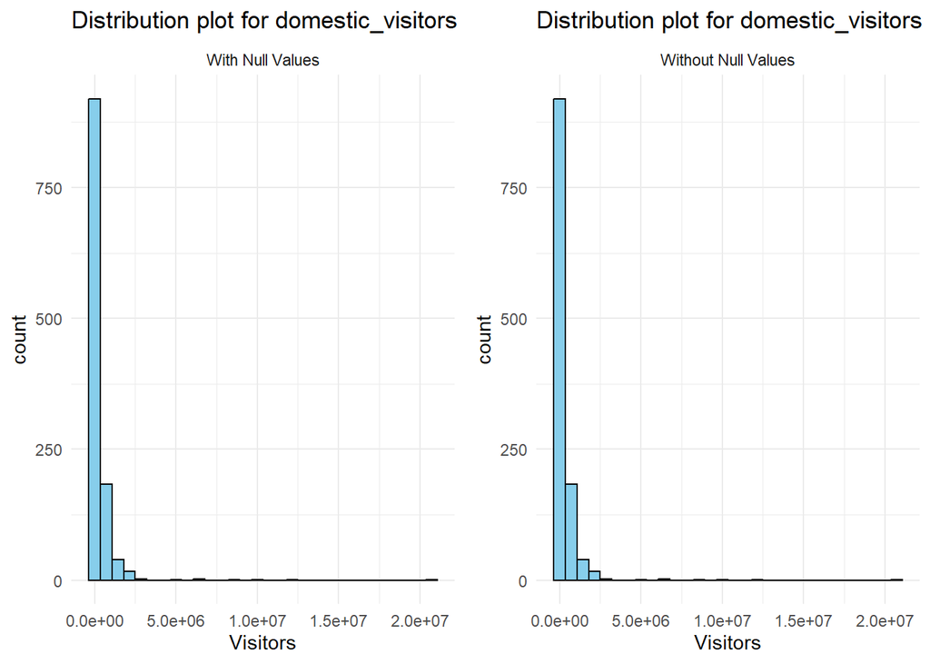

```r
plot_before_after_NA <- function(data_with_na, data_without_na,main1=NULL) {
  # Histogram of visitors with NA values
  df_with_na <- ggplot(data = data_with_na, aes(x = visitors)) +
    geom_histogram(fill = "skyblue", color = "black", bins = 30, na.rm = FALSE) +
    labs(title = "Distribution of Visitors with Null Values", x = "Visitors") +
    theme_minimal() +ggtitle(main1)

  # Histogram of visitors after removing NA values
  df_without_na <- ggplot(data = data_without_na, aes(x = visitors)) +
    geom_histogram(fill = "skyblue", color = "black", bins = 30, na.rm = TRUE) +
    labs(title = "Distribution of Visitors after removing Null Values", x = "Visitors") +
    theme_minimal() + ggtitle(main1)

  # Combine both histograms into a single plot using facets
  combined_plot <- cowplot::plot_grid(
    df_with_na + facet_wrap(~ "With Null Values"),
    df_without_na + facet_wrap(~ "Without Null Values"),
    ncol = 2
  )

  # Display the combined plot
  print(combined_plot)
}

# Example usage of the function with your dataframes
plot_before_after_NA(domestic_vis, cleaned_domestic_vis , "Distribution plot for domestic_visitors")
```

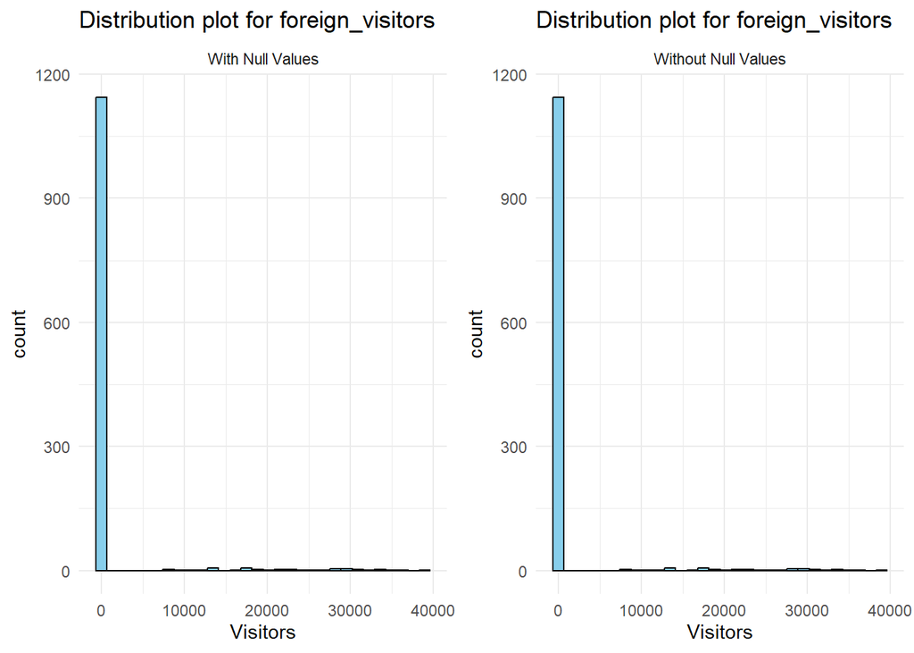

```r
plot_before_after_NA(foreign_vis, cleaned_foreign_vis , "Distribution plot for foreign_visitors")
```

```r
total_rows_clean_d <- nrow(cleaned_domestic_vis)
total_rows_clean_f <- nrow(cleaned_foreign_vis)

total_missing_clean_d <- sum(is.na(cleaned_domestic_vis$visitors))
total_missing_clean_f <- sum(is.na(cleaned_foreign_vis$visitors))

percentage_missing_clean_d <- (total_missing_clean_d / total_rows_clean_d) * 100
percentage_missing_clean_f <- (total_missing_clean_f / total_rows_clean_f) * 100
# paste(percentage_missing_clean_d,"Remaining missing values for domestic_vis")
# paste(percentage_missing_clean_f,"Remaining missing values for foreign_vis")
```

#### But even after removing those districts with null values we have **14.69%** null values remaining.

#### Similarly even after removing those districts with null values we have **`12.87%** null values remaining.

#### So we will impute the data with the Mean with respect to districts.

#### And then we will again plot distribution of data to make sure imputation doesn’t change the distribution of original data.

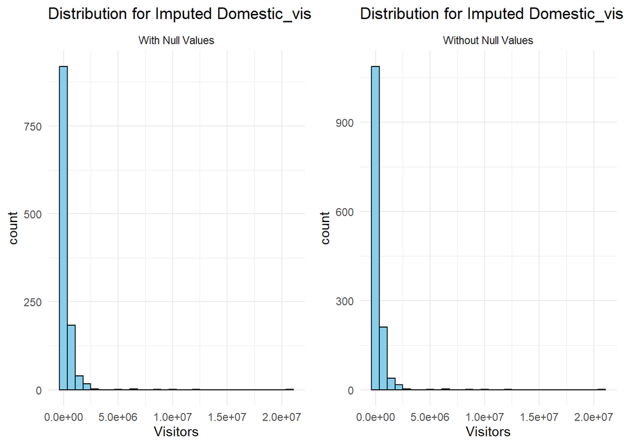

```r
# mean_visitors_d <- mean(cleaned_domestic_vis$visitors, na.rm = TRUE)
# mean_visitors_f <- mean(cleaned_foreign_vis$visitors, na.rm = TRUE)
#
# cleaned_domestic_vis$visitors[is.na(cleaned_domestic_vis$visitors)] <- mean_visitors_d
# cleaned_foreign_vis$visitors[is.na(cleaned_foreign_vis$visitors)] <- mean_visitors_f
#
# imputed_data_d = cleaned_domestic_vis
# imputed_data_f = cleaned_foreign_vis

# imputed_data_d <- cleaned_domestic_vis %>%
#   group_by(district) %>%
#   mutate(visitors = ifelse(is.na(visitors), mean(visitors, na.rm = TRUE), visitors))
#
# imputed_data_f <- cleaned_foreign_vis %>%
#   group_by(district) %>%
#   mutate(visitors = ifelse(is.na(visitors), mean(visitors, na.rm = TRUE), visitors))

# imputed_data_d <- cleaned_domestic_vis %>%
#   group_by(district, year) %>%
#   mutate(visitors = ifelse(is.na(visitors), mean(visitors, na.rm = TRUE), visitors))
#
# imputed_data_f <- cleaned_foreign_vis %>%
#   group_by(district, year) %>%
#   mutate(visitors = ifelse(is.na(visitors), mean(visitors, na.rm = TRUE), visitors))

imputed_data_d <- cleaned_domestic_vis %>%
  group_by(district) %>%
  mutate(visitors = ifelse(is.na(visitors), round(mean(visitors[year == 2017], na.rm = TRUE)), visitors))

imputed_data_f <- cleaned_foreign_vis %>%
  group_by(district) %>%
  mutate(visitors = ifelse(is.na(visitors), round(mean(visitors[year == 2017], na.rm = TRUE)), visitors))


plot_before_after_NA(cleaned_domestic_vis , imputed_data_d ,"Distribution for Imputed Domestic_vis")
```

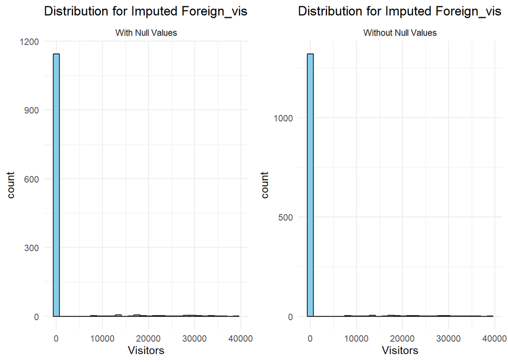

```r
plot_before_after_NA(cleaned_foreign_vis , imputed_data_f , "Distribution for Imputed Foreign_vis")
```

```r
total_missing_values_d <- sum(is.na(imputed_data_d$visitors))
paste(total_missing_values_d, "null values in domestic_vis")
```

```
## [1] "6 null values in domestic_vis"
```

```r
domestic_vis = imputed_data_d


total_missing_values_f <- sum(is.na(imputed_data_f$visitors))
paste(total_missing_values_f, "null values in foreign_vis")
```

```
## [1] "0 null values in foreign_vis"
```

```r
foreign_vis = imputed_data_f
```

# Data Analysis

### Top 10 Districts with highest visitors

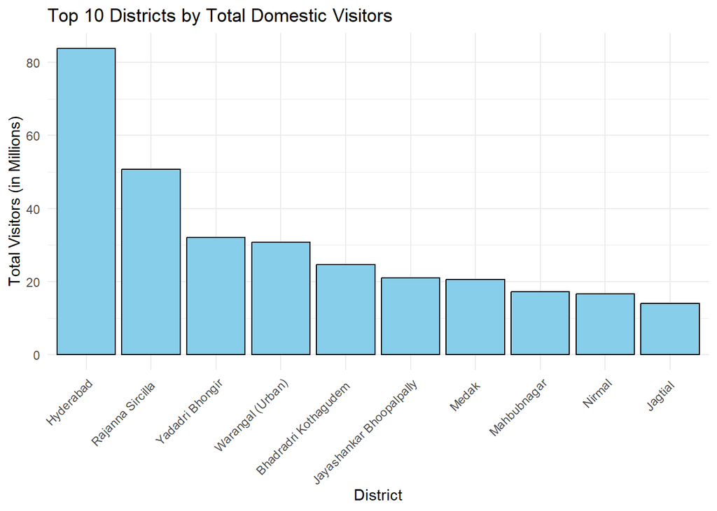

```r
#Creating a function to get top 10 districts and bar plot
top_10_districts =function( visitors_df,type="domestic"){

  # Group by district, calculate the sum of visitors, and select the top 10 districts

  top_10_districts_df <- visitors_df %>%
  group_by(district) %>%
  summarise(total_visitors = sum(visitors,na.rm = T)) %>%
  arrange(desc(total_visitors)) %>%
  head(10)

  # convert into million on for domestic visitors
  if (type=="domestic"){
    top_10_districts_df$total_visitors <- top_10_districts_df$total_visitors / 1000000

  }

  bar_plot =ggplot(top_10_districts_df, aes(x = reorder(district,-total_visitors), y = total_visitors)) +
  geom_bar(stat = "identity", fill = "skyblue",color='black') +
  # scale_y_continuous(labels = scales::comma) +
  labs(title = "Top 10 Districts by Total Domestic Visitors",
          x = "District", y = "Total Visitors (in Millions)") +
  theme_minimal() +
  theme(axis.text.x = element_text(angle = 45, hjust = 1))



  return( list("df"= top_10_districts_df,"bar_plot"=bar_plot))
}
dom_top_10_dis = top_10_districts(domestic_vis)
print(dom_top_10_dis$bar_plot)
```

```r
fore_top_10_dis = top_10_districts(foreign_vis,type="foreign")
print(fore_top_10_dis$df)
```

```
## # A tibble: 10 × 2
##    district                   total_visitors
##    <chr>                               <dbl>
##  1 "Hyderabad"                       1044898
##  2 "Warangal (Urban)"                   8821
##  3 "Mahbubnagar"                        2282
##  4 "Jayashankar Bhoopalpally"           1684
##  5 "Jogulamba Gadwal "                  1170
##  6 "Nagarkurnool "                       995
##  7 "Mulugu"                              575
##  8 "Warangal (Rural)"                    540
##  9 "Adilabad"                             32
## 10 "Mancherial"                           10
```

### Top and Bottom 3 CAGR districts for domestic visitors

```r
total_vis_year <- domestic_vis %>%
  group_by(district, year) %>%
  summarise(visitors = sum(visitors, na.rm = T))

# Get unique districts for the year 2016
districts <- domestic_vis %>%
  filter(year == 2016) %>%
  select(district) %>%
  distinct() %>%
  pull()

# Function to calculate CAGR
calculate_cagr <- function(district_name) {
  fv <- total_vis_year %>% filter(district == district_name & year == 2019) %>% pull(visitors)
  pv <- total_vis_year %>% filter(district == district_name & year == 2016) %>% pull(visitors)


  if ( pv != 0) {
    cagr <- ((fv/pv)^(1/3) - 1) * 100
    return(c(district = district_name, cagr = round(cagr,2)))
  } else {
    return(c(district = district_name, cagr = 0) )
  }
}

# Apply the function to each district
cagr_list <- map_df(districts, calculate_cagr)

# Create a data frame from the list
district_cagr <- as.data.frame(cagr_list)
district_cagr$cagr = as.numeric(district_cagr$cagr)

# Get top and bottom 3 districts by CAGR
top3_districts_cagr <- district_cagr %>% arrange(desc(cagr)) %>% slice_head(n = 3)
bottom3_districts_cagr <- district_cagr %>% arrange(cagr) %>% slice_head(n = 3)

# Print the results
```

##### Top 3 Districts by CAGR:

```
##                district  cagr
## 1             Nizamabad 93.03
## 2 Bhadradri Kothagudem  47.93
## 3      Warangal (Rural) 40.45
```

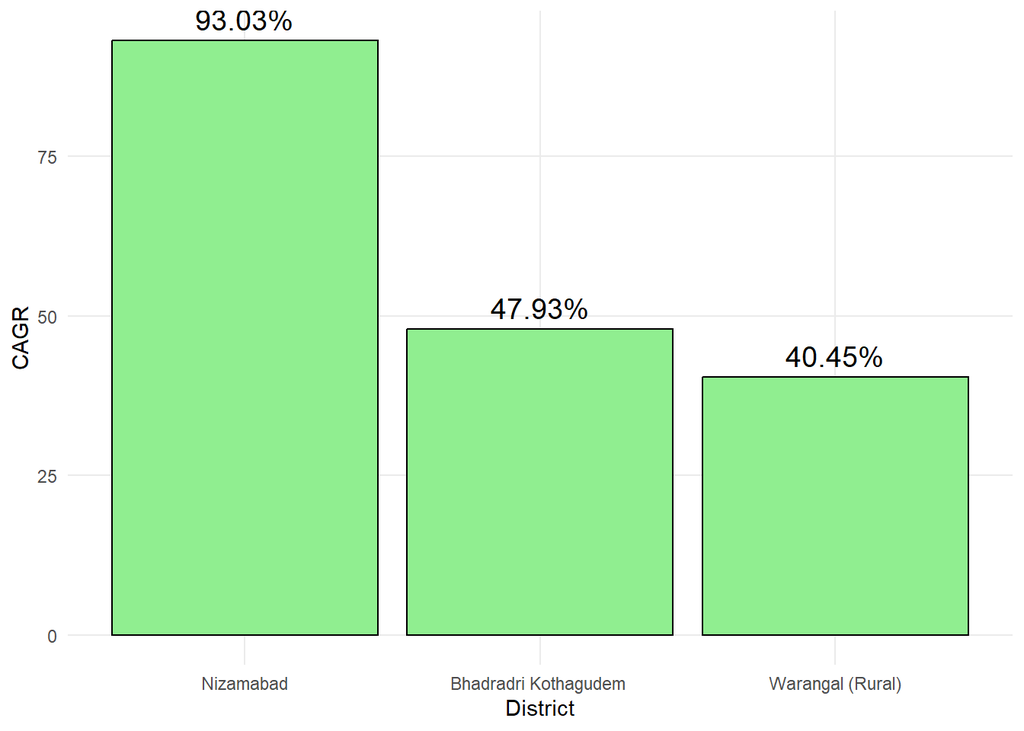

##### Bottom 3 Districts by CAGR:

```
##           district   cagr
## 1      Karimnagar  -79.63
## 2         Nalgonda -71.13
## 3 Warangal (Urban) -58.86
```

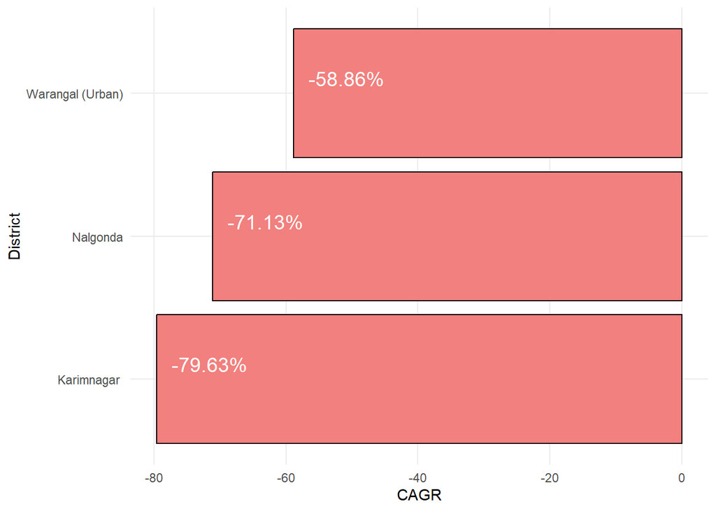

### Peak and Low Season for Hyderabad District

```r
month_wise_hyb = function(vis_df){

  month_wise_hyb_df <- vis_df %>%
  filter(district == 'Hyderabad') %>%
  group_by(district, month) %>%
  summarize(visitors = sum(visitors))

  month_with_max_vis <- month_wise_hyb_df %>%
  filter(visitors == max(visitors))

  month_with_min_vis <- month_wise_hyb_df %>%
  filter(visitors == min(visitors))

  return (list('df'=month_wise_hyb_df, 'max_vis'=month_with_max_vis, 'min_vis'=month_with_min_vis))

}

month_wise_hyb_dom <- month_wise_hyb(domestic_vis)
month_wise_hyb_fore <- month_wise_hyb(foreign_vis)

# Find the month with the maximum visitors
month_with_max_vis_dom <- month_wise_hyb_dom$max_vis
month_with_max_vis_fore <- month_wise_hyb_fore$max_vis

# Find the month with the minimum visitors

month_with_min_vis_dom <- month_wise_hyb_dom$min_vis
month_with_mix_vis_fore <- month_wise_hyb_fore$min_vis
```

```
Month with highest domestic visitors June , visitors: 16.898 Million

Month with lowest Domestic visitors  February, visitors: 5.01443\times 10^{6}


Month with highest Foreign visitors December , visitors: 0.12 Million

Month with lowest Foreign visitors  May, visitors: 6.0376\times 10^{4}
```

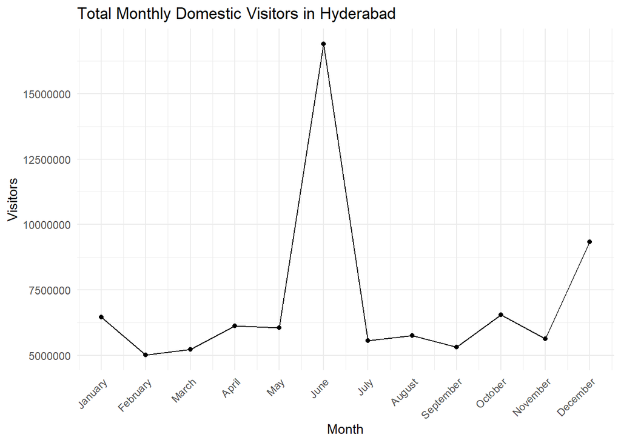

```r
# Create a mapping of month names to numeric values
month_mapping <- c("January" = 1, "February" = 2, "March" = 3, "April" = 4,
                   "May" = 5, "June" = 6, "July" = 7, "August" = 8,
                   "September" = 9, "October" = 10, "November" = 11, "December" = 12)

# Use dplyr to create a new numeric 'month_num' column
month_wise_hyb_dom <- month_wise_hyb_dom$df %>%
  mutate(month_num = match(month, names(month_mapping)))

month_wise_hyb_fore <- month_wise_hyb_fore$df %>%
  mutate(month_num = match(month, names(month_mapping)))

# Create the time series plot using 'month_num' as x-axis
dom_plot =ggplot(month_wise_hyb_dom, aes(x = month_num, y = visitors)) +
  # geom_line() +
  geom_line() +
  geom_point(alpha=1) +
  labs(title = "Total Monthly Domestic Visitors in Hyderabad",
       x = "Month",
       y = "Visitors") +
  scale_x_continuous(breaks = 1:12, labels = names(month_mapping)) + # Customize x-axis labels
  theme_minimal() +
  theme( axis.text.x = element_text(angle = 45, hjust = 1) )

fore_plot = ggplot(month_wise_hyb_fore, aes(x = month_num, y = visitors)) +
  geom_line() +
  geom_point(alpha=1) +
  labs(title = "TOtal Monthly Foreign Visitors in Hyderabad",
       x = "Month",
       y = "Visitors") +
  scale_x_continuous(breaks = 1:12, labels = names(month_mapping)) + # Customize x-axis labels
  theme_minimal() +
  theme(axis.text.x = element_text(angle = 45, hjust = 1))



print(dom_plot)
```

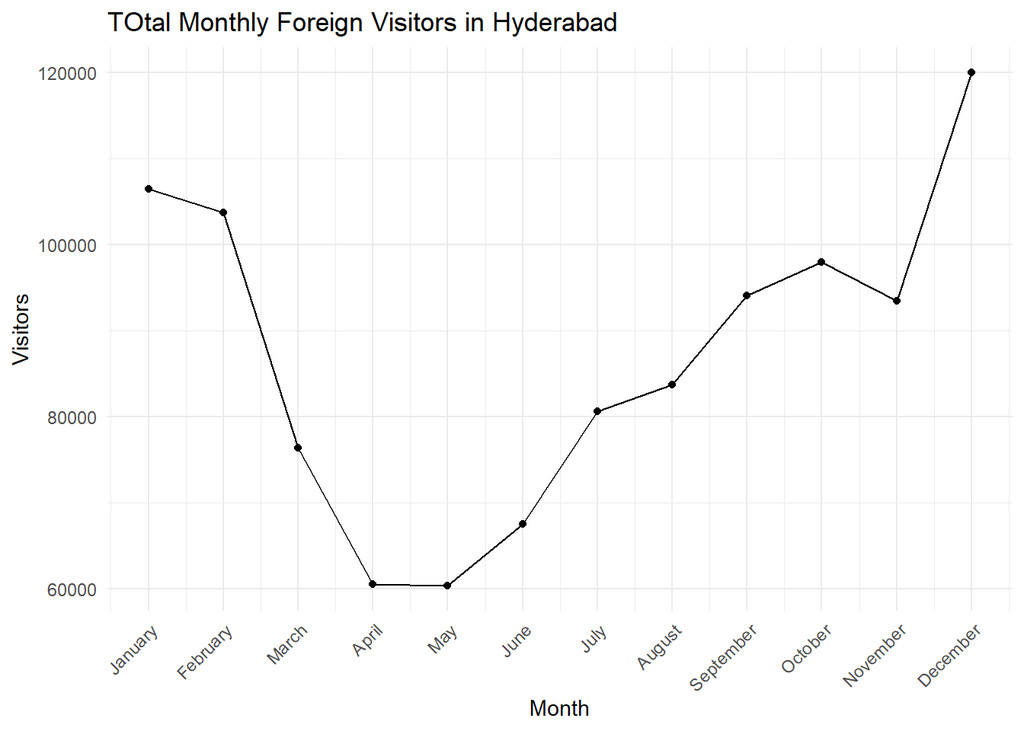

```r
print(fore_plot)
```

### Year wise monthly trends of Top Districts

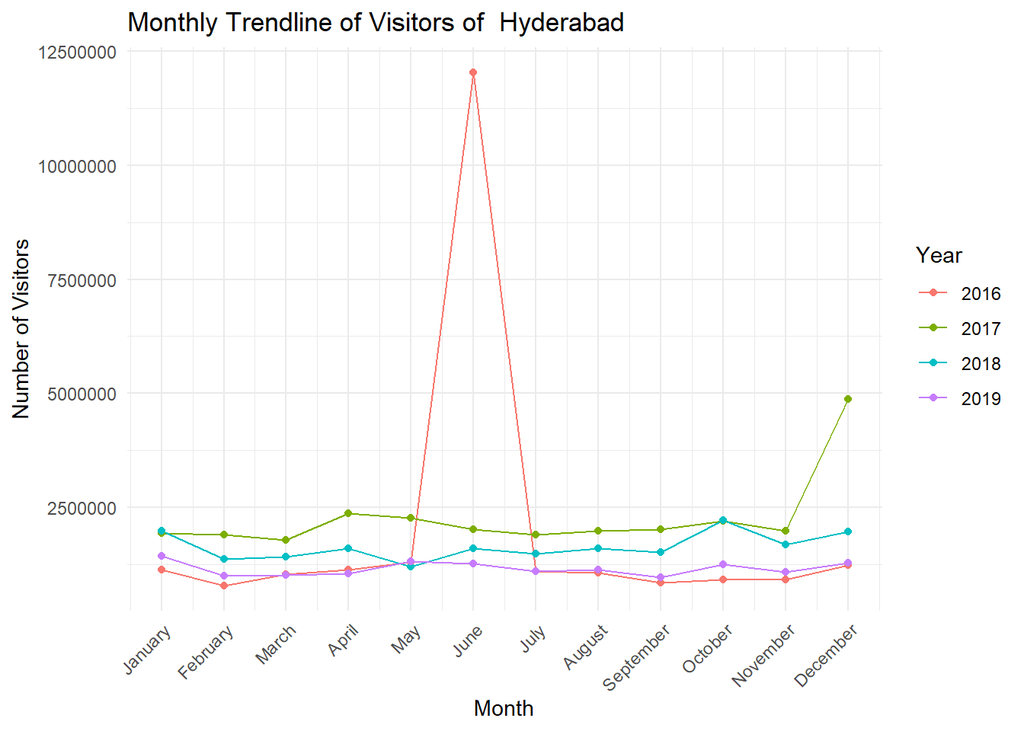

```r
month_wise_year_plot = function(vis_df, district_name) {
  month_wise <- vis_df %>%
    filter(district == district_name) %>%
    group_by(district, month, year) %>%
    summarize(visitors = sum(visitors,na.rm=T))

  # Create a mapping of month names to numeric values
  month_mapping <- c("January" = 1, "February" = 2, "March" = 3, "April" = 4,
                     "May" = 5, "June" = 6, "July" = 7, "August" = 8,
                     "September" = 9, "October" = 10, "November" = 11, "December" = 12)

  # Use dplyr to create a new numeric 'month_num' column
  month_wise <- month_wise %>%
    mutate(month_num = match(month, names(month_mapping)))

  plot = ggplot(month_wise, aes(x = month_num, y = visitors, group = factor(year), color = factor(year))) +
    geom_line() +
      geom_point(alpha=1) +
    labs(title = paste("Monthly Trendline of Visitors of ", district_name),
         x = "Month",
         y = "Number of Visitors",
         color = "Year") +
    scale_x_continuous(breaks = 1:12, labels = names(month_mapping)) +  # Customize x-axis labels
    theme_minimal() +
    theme( axis.text.x = element_text(angle = 45, hjust = 1) )

  return (plot)
}
  hyd_dom_plot = month_wise_year_plot(domestic_vis, "Hyderabad")
  hyd_fore_plot = month_wise_year_plot(foreign_vis, "Hyderabad")
  hyd_dom_plot
```

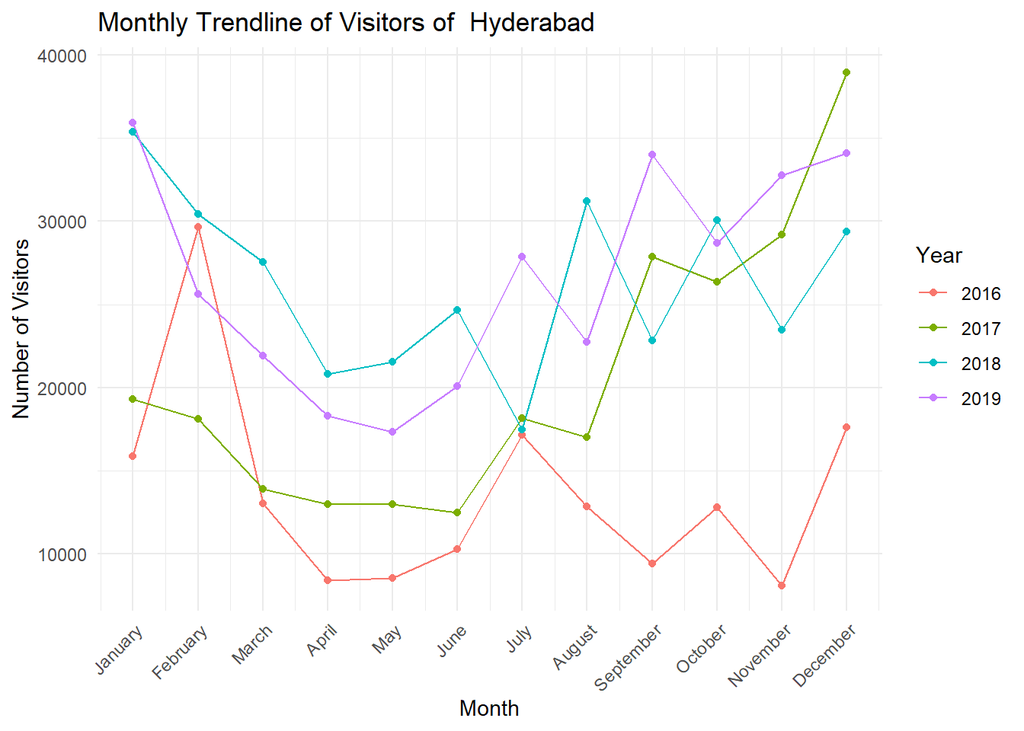

```r
  hyd_fore_plot
```

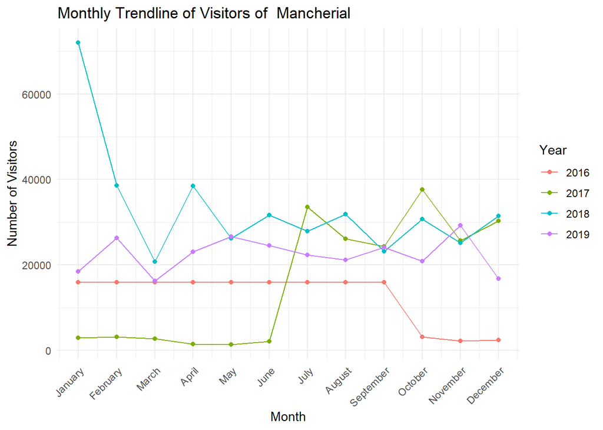

```r
  mancherial_dom_plot = month_wise_year_plot(domestic_vis, "Mancherial")
  mancherial_dom_plot
```

### Top and Bottom 3 district in terms of domestic to foreign tourist raito

```r
# Merge data frames on 'district', 'date', 'month', and 'year'
dom_for_v <- inner_join(domestic_vis, foreign_vis, by = c('district', 'date', 'month', 'year'))

# Rename columns if needed
dom_for_v <- rename(dom_for_v, domestic_vis = visitors.x, foreign_vis = visitors.y)

# Group by 'district' and calculate the sum of 'domestic_vis' and 'foreign_vis'
dom_for_v_dis_sum <- dom_for_v %>%
  group_by(district) %>%
  summarise(domestic_vis = sum(domestic_vis,na.rm=T), foreign_vis = sum(foreign_vis,na.rm=T))

# Remove rows where 'foreign_vis' is zero
dom_for_v_dis_sum <- dom_for_v_dis_sum %>% filter(foreign_vis != 0)

# Calculate the ratio of 'domestic_vis' to 'foreign_vis'
dom_for_v_dis_sum <- dom_for_v_dis_sum %>%  mutate(dom_foreign_ratio = domestic_vis / foreign_vis)

# Find the top 3 and bottom 3 districts based on 'dom_foreign_ratio'
bottom_3_districts <- dom_for_v_dis_sum %>% arrange(desc(dom_foreign_ratio)) %>% select(district, dom_foreign_ratio) %>%  slice_head(n = 3)
top_3_districts <- dom_for_v_dis_sum %>% arrange(dom_foreign_ratio) %>% select(district, dom_foreign_ratio) %>% slice_head(n = 3)


print(bottom_3_districts)
```

```
## # A tibble: 3 × 2
##   district   dom_foreign_ratio
##   <chr>                  <dbl>
## 1 "Nirmal"            8309803
## 2 "Jangaon "           475280.
## 3 "Adilabad"           228799.
```

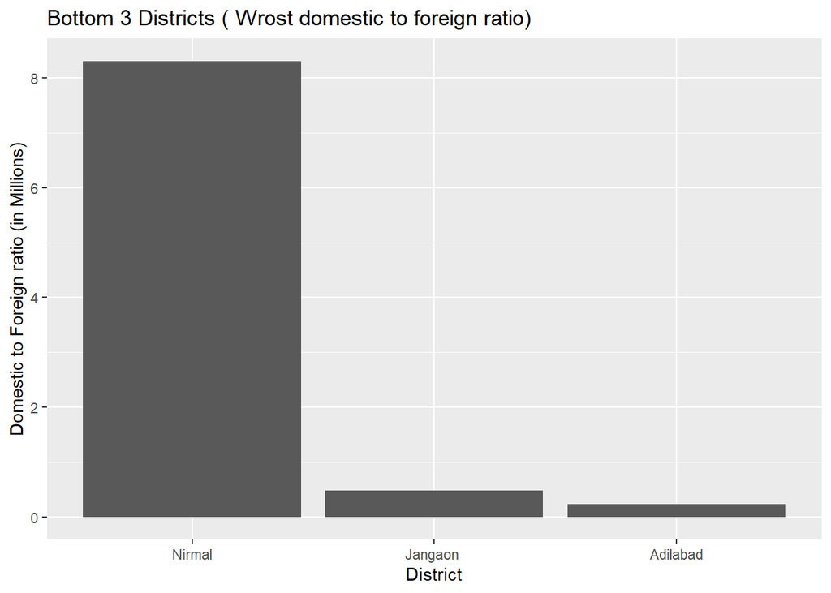

```r
ggplot(bottom_3_districts, aes(x= reorder(district, -dom_foreign_ratio),y=dom_foreign_ratio/1000000))+
  geom_bar(stat='identity') +
  labs( title = "Bottom 3 Districts ( Wrost domestic to foreign ratio)",
        x = "District",
        y = "Domestic to Foreign ratio (in Millions)")
```

```r
print(top_3_districts)
```

```
## # A tibble: 3 × 2
##   district         dom_foreign_ratio
##   <chr>                        <dbl>
## 1 Hyderabad                     80.3
## 2 Warangal (Rural)            1717.
## 3 Mulugu                      3165.
```

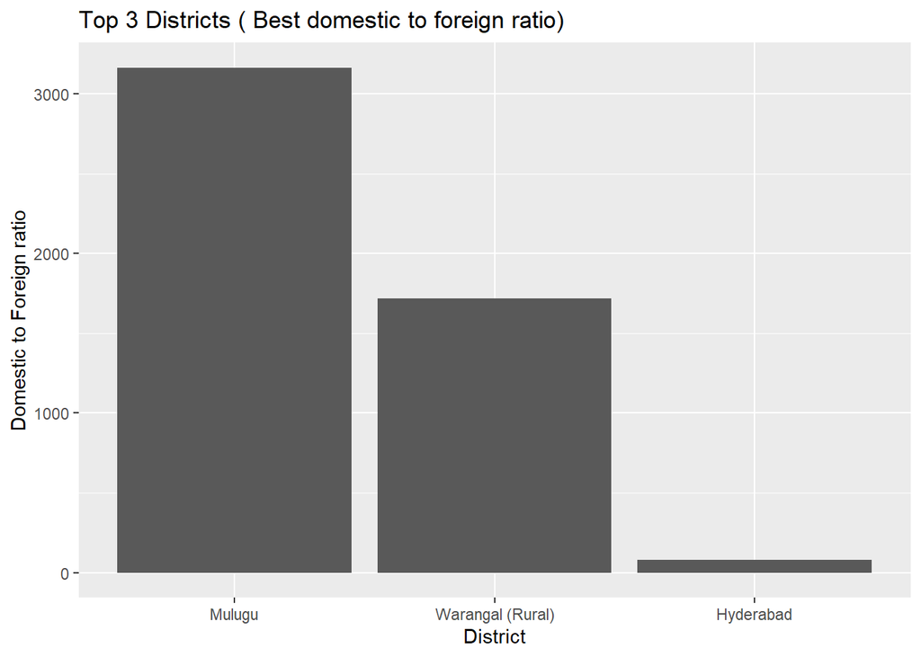

```r
ggplot(top_3_districts , aes(x= reorder(district, -dom_foreign_ratio),y=dom_foreign_ratio))+
  geom_bar(stat='identity') +
  labs( title = "Top 3 Districts ( Best domestic to foreign ratio)",
        x = "District",
        y = "Domestic to Foreign ratio")
```

### Population to Tourist footfall ratio

```r
population = read.csv('./population.csv')
head(population)
```

```
##                   district Population_2011 Population_2019
## 1                 Adilabad          708972          755637
## 2    Bhadradri Kothagudem          1069261         1139641
## 3                Hyderabad         3943323         4202876
## 4                 Jagtial           985417         1050278
## 5                 Jangaon           566376          603655
## 6 Jayashankar Bhoopalpally          711434          758261
```

```r
dom_for_v_dis_2019 = dom_for_v %>% filter(year == '2019')

dom_for_v_dis_sum_2019= dom_for_v_dis_2019 %>%
  group_by(district) %>%
  summarise(domestic_vis = sum(domestic_vis,na.rm=T), foreign_vis = sum(foreign_vis,na.rm=T))

data_with_population <- left_join(dom_for_v_dis_sum_2019, population, by = c('district'))



dom_for_v_dis_sum_pop <- data_with_population %>%  mutate(dom_foreign_sum = domestic_vis + foreign_vis)
dom_for_v_dis_sum_pop <- dom_for_v_dis_sum_pop %>% filter(dom_foreign_sum != 0)


dom_for_v_dis_sum_pop <- dom_for_v_dis_sum_pop %>%
                          mutate(dom_foreign_pop_ratio = dom_foreign_sum / Population_2019 )

dom_for_v_dis_sum_pop_top5 = dom_for_v_dis_sum_pop %>% select(district,dom_foreign_pop_ratio) %>%
                              arrange(desc(dom_foreign_pop_ratio)) %>%
                                slice_head(n = 5)

dom_for_v_dis_sum_pop_bottom5 = dom_for_v_dis_sum_pop %>% select(district,dom_foreign_pop_ratio) %>%
  arrange(dom_foreign_pop_ratio) %>%
  slice_head(n = 5)

dom_for_v_dis_sum_pop_top5
```

```
## # A tibble: 5 × 2
##   district                dom_foreign_pop_ratio
##   <chr>                                   <dbl>
## 1 "Rajanna Sircilla "                     28.6
## 2 "Bhadradri Kothagudem "                 11.2
## 3 "Medak "                                 6.67
## 4 "Yadadri Bhongir"                        5.70
## 5 "Nirmal"                                 5.05
```

```r
dom_for_v_dis_sum_pop_bottom5
```

```
## # A tibble: 5 × 2
##   district                 dom_foreign_pop_ratio
##   <chr>                                    <dbl>
## 1 "Kamareddy "                          0.000515
## 2 "Peddapalli"                          0.0196
## 3 "Nizamabad"                           0.0277
## 4 "Komaram Bheem Asifabad"              0.0349
## 5 "Karimnagar "                         0.0723
```

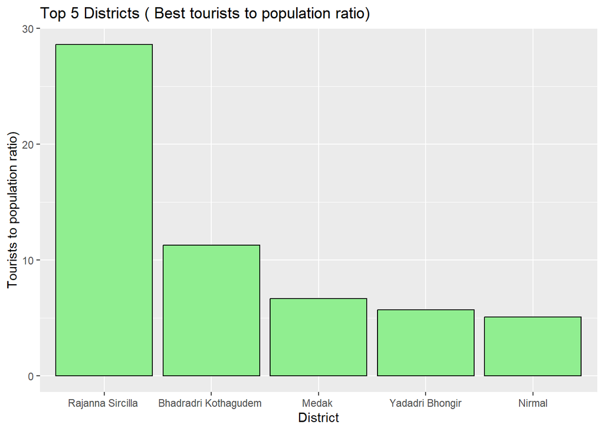

```r
ggplot(dom_for_v_dis_sum_pop_top5 , aes(x= reorder(district, -dom_foreign_pop_ratio),y=dom_foreign_pop_ratio))+
  geom_bar(stat='identity',fill='lightgreen',color='black') +
  labs( title = "Top 5 Districts ( Best tourists to population ratio)",
        x = "District",
        y = "Tourists to population ratio)")
```

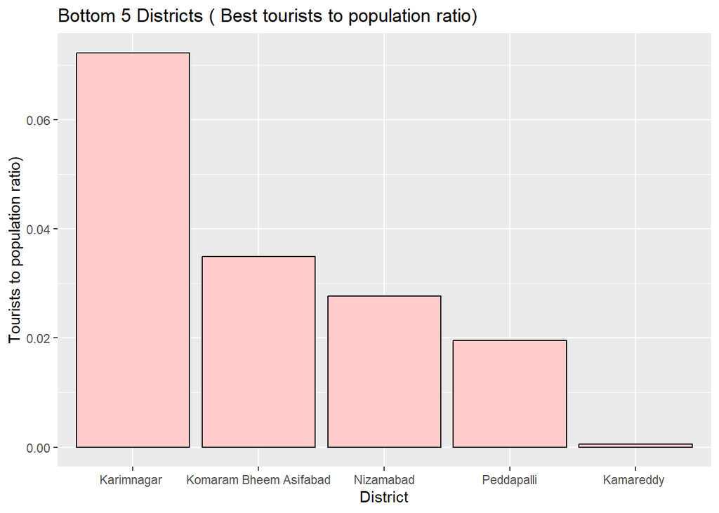

```r
ggplot(dom_for_v_dis_sum_pop_bottom5 , aes(x= reorder(district, -dom_foreign_pop_ratio),y=dom_foreign_pop_ratio))+
  geom_bar(stat='identity',fill='#ffcccb',color='black') +
  labs( title = "Bottom 5 Districts ( Best tourists to population ratio)",
        x = "District",
        y = "Tourists to population ratio)")
```

### Conclusion

##### Hyderabad

> Hyderabad is a major economic and cultural hub in South India, attracting a large number of domestic and foreign tourists to its historical landmarks and business centers. Must visit places
- Charminar
- Golconda Fort
- Qutb Shahi Tombs
- Ramoji Film City

##### Mancherial

> Mancherial has strong contributions from coal mining and diverse industrial development, along with a favourable climate for agriculture and significant infrastructure
- Coal Mines and Singareni Collieries Company Limited (SCCL) areas
- Kawal Tiger Reserve
- Sri Satyanarayana Swamy Temple